# R Notebook

## Load the data

```r
library(tidyverse)
library(jsonlite)
```

```r
result2 <- read_json(path = "data/NarrativeData_000.json")
```

[output not shown]

Load the text data

```r
# list of files to read
json_files <- list.files(path = "data", pattern="*.json", full.names = T)

# read data into list
big_list <- lapply(json_files, function(x) read_json(x, simplifyVector = T))

# create data.frame from list
df_text <- do.call(rbind, flatten(big_list))
```

[output not shown]

# Text Analyis

a token is a word (or another unit of text)

```r
library(tidytext)
data(stop_words)

# count the words
tidy_narrative <- df %>%
  select(EventID, narrative) %>%
  unnest_tokens(word, narrative) %>% #token = "ngrams", n = 2
  anti_join(stop_words) %>%
  mutate(word = str_replace_all(word, "[:digit:]", "")) %>% # remove numbers
  mutate(word = str_replace_all(word, "[[:punct:]]", "")) %>% # remove punctuation
  mutate(word = na_if(word, "")) %>%
  drop_na() %>%
  count(EventID, word, sort = T)

# tf-idf
df_tfidf <- tidy_narrative %>%
  bind_tf_idf(word, EventID, n)
```

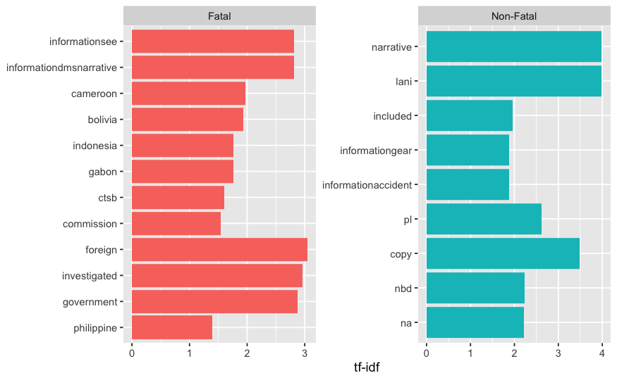

```r
# plot tf-idf for accident type
df_tfidf %>%
  left_join(df) %>%
  filter(InvestigationType == "Accident") %>% # remove incidents, which are always non-fatal
  mutate(InjuryType = ifelse(InjurySeverity %in% c("Non-Fatal", "Unavailable"), as.character(InjurySeverity), "Fatal")) %>%
  filter(!(InjuryType %in% c("Unavailable"))) %>% # remove missing values
  group_by(InjuryType) %>%
  slice_max(tf_idf, n=15) %>%
  ungroup() %>%
  mutate(word = reorder(word, tf_idf)) %>%
  ggplot(aes(tf_idf, word, fill = InjuryType)) +
  geom_col(show.legend = FALSE) +
  labs(x = "tf-idf", y = NULL) +
  facet_wrap(~InjuryType, ncol = 2, scales = "free")
```

Insights: Foreign governments are bad news!

Now step away from Tidy and try the old fashioned way.

```r
library(tm)

# subset the data
tmp <- df %>%
  filter(InvestigationType == "Accident") %>% # remove incidents, which are always non-fatal
  mutate(InjuryType = ifelse(InjurySeverity %in% c("", "Non-Fatal", "Unavailable"), as.character(InjurySeverity), "Fatal")) %>%
  filter(InjuryType %in% c("Fatal", "Non-Fatal")) %>% # remove missing values
  mutate(InjuryTypeBin = ifelse(InjuryType=="Fatal", 1, 0))


# create corpus
corpus <- Corpus(VectorSource(tmp$narrative))

# remove line breaks
line_break <- function(x) gsub("\\\\r\\\\n", " ", x)
docs.s <- tm_map(corpus, line_break)
```

```
transformation drops documents
```

```r
# remove stop words
docs.s <- tm_map(docs.s, removeWords, stopwords("english"))
```

```
transformation drops documents
```

```r
# remove upper-case
docs.s <- tm_map(docs.s, content_transformer(tolower))
```

```
transformation drops documents
```

```r
# remove punctuation
docs.s <- tm_map(docs.s, removePunctuation, preserve_intra_word_dashes = TRUE)
```

```
transformation drops documents
```

```r
# remove numbers
docs.s <- tm_map(docs.s, removeNumbers)
```

```
transformation drops documents
```

```r
# remove left over "th" from numbers
docs.s <- tm_map(docs.s, removeWords, c("th"))
```

```
transformation drops documents
```

```r
# remove white Space
docs.s <- tm_map(docs.s, stripWhitespace)
```

```
transformation drops documents
```

```r
# check the first entry
docs.s[[1]]$content
```

```r
# create DTM
dtm <- DocumentTermMatrix(docs.s)

# remove sparse terms
dtm = removeSparseTerms(dtm, 0.99)

library(wordcloud)
# generate word cloud
freq = data.frame(sort(colSums(as.matrix(dtm)), decreasing=TRUE))
wordcloud(rownames(freq), freq[,1], max.words=40, colors=brewer.pal(1, "Dark2"))
```

[output not shown]

```r
# tf-idf
dtm_tfidf <- DocumentTermMatrix(docs.s, control = list(weighting = weightTfIdf))

# remove sparse terms
dtm_tfidf = removeSparseTerms(dtm_tfidf, 0.99)

# generate word cloud
freq = data.frame(sort(colSums(as.matrix(dtm_tfidf)), decreasing=TRUE))
wordcloud(rownames(freq), freq[,1], max.words=40, colors=brewer.pal(1, "Dark2"))
```

[output not shown]

```r
# convert if-idf DTM to matrix
DF <- as.matrix(dtm_tfidf)

# convert grade levels to matrix of numerical factors
target <- as.matrix(tmp$InjuryTypeBin)

# split data into training and testing sets
set.seed(123)
smp_size <- floor(0.75 * nrow(DF))
train_ind <- sample(seq_len(nrow(DF)), size = smp_size)

train.x <- DF[train_ind, ]
train.y <- target[train_ind,]
test.x <- DF[-train_ind, ]
test.y <- target[-train_ind,]
```

```r
library(glmnet)
# fit model
cvfit=cv.glmnet(train.x[1:5000,], train.y[1:5000], # sample to save computation time
                family="binomial",
                type.measure = "auc")

# plot the penalization parameter against the auc
plot(cvfit)
```

[output not shown]

```r
# extract coefficient values for optimal lambda
tmp_coeffs <- coef(cvfit, s = "lambda.min")

# put word names and coefs into data frame
df_plot <- data.frame(words = colnames(DF)[tmp_coeffs@i], # extract words
                    coefs = tmp_coeffs@x[-1]) # extract coefs except intercept

# plot
df_plot %>%
  arrange(desc(coefs)) %>%
  top_n(15) %>%
  ggplot(aes(x=reorder(words, coefs), y=coefs)) +
  geom_bar(stat = "identity") +
  coord_flip() +
  labs(y = "coefficient",
       x = NULL,
       title = "What words were commonly used in narratives of fatal accidents?",
       subtitle = "Words selected by regularized logistic regression model")

# plot
df_plot %>%
  arrange(desc(coefs)) %>%
  top_n(-15) %>%
  ggplot(aes(x=reorder(words, coefs), y=coefs)) +
  geom_bar(stat = "identity") +
  coord_flip() +
  labs(y = "coefficient",
       x = NULL,
       title = "What words were commonly used in narratives of non-fatal accidents?",
       subtitle = "Words selected by regularized logistic regression model")
```

[output not shown]

maybe standardize the coefs somehow? There is a standardize coefs argument in the glmnet function.

Now try the probably cause column

```r
# create new corpus with the probable cause report
corpus <- Corpus(VectorSource(tmp$probable_cause))

line_break <- function(x) gsub("\\\\r\\\\n", " ", x)

docs.s <- tm_map(corpus, line_break)
```

```
transformation drops documents
```

```r
docs.s <- tm_map(docs.s, removeWords, stopwords("english"))
```

```
transformation drops documents
```

```r
docs.s <- tm_map(docs.s, content_transformer(tolower))
```

```
transformation drops documents
```

```r
docs.s <- tm_map(docs.s, removePunctuation, preserve_intra_word_dashes = TRUE)
```

```
transformation drops documents
```

```r
docs.s <- tm_map(docs.s, removeNumbers)
```

```
transformation drops documents
```

```r
docs.s <- tm_map(docs.s, removeWords, c("th"))
```

```
transformation drops documents
```

```r
docs.s <- tm_map(docs.s, stripWhitespace)
```

```
transformation drops documents
```

```r
# create DTM
dtm <- DocumentTermMatrix(docs.s)

# remove sparse terms
dtm = removeSparseTerms(dtm, 0.99)

# tf-idf
dtm_tfidf <- DocumentTermMatrix(docs.s, control = list(weighting = weightTfIdf))
```

[output not shown]

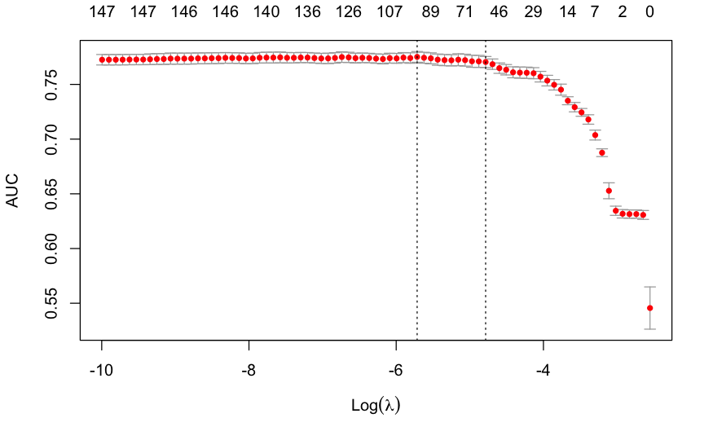

```r
# remove sparse terms
dtm_tfidf = removeSparseTerms(dtm_tfidf, 0.99)

# convert if-idf DTM to matrix
DF <- as.matrix(dtm_tfidf)

# response varible (fatality)
target <- as.matrix(tmp$InjuryTypeBin)

# split data into training and testing sets
set.seed(123)
smp_size <- floor(0.75 * nrow(DF))
train_ind <- sample(seq_len(nrow(DF)), size = smp_size)

train.x <- DF[train_ind, ]
train.y <- target[train_ind,]
test.x <- DF[-train_ind, ]
test.y <- target[-train_ind,]

# fit model
cvfit=cv.glmnet(train.x[1:5000,], train.y[1:5000], # sample to save computation time
                family="binomial",
                type.measure = "auc")

# plot the penalization parameter against the auc
plot(cvfit)
```

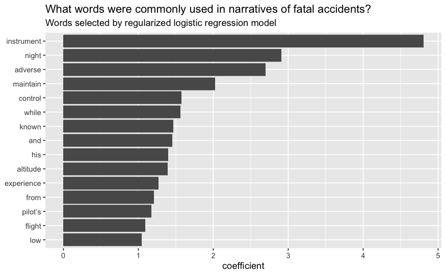

```r
# extract coefficient values for optimal lambda
tmp_coeffs <- coef(cvfit, s = "lambda.min")

# put word names and coefs into data frame
df_plot <- data.frame(words = colnames(DF)[tmp_coeffs@i], # extract words
                    coefs = tmp_coeffs@x[-1]) # extract coefs except intercept

# plot
df_plot %>%
  arrange(desc(coefs)) %>%
  top_n(15) %>%
  ggplot(aes(x=reorder(words, coefs), y=coefs)) +
  geom_bar(stat = "identity") +
  coord_flip() +
  labs(y = "coefficient",
       x = NULL,
       title = "What words were commonly used in narratives of fatal accidents?",
       subtitle = "Words selected by regularized logistic regression model")
```

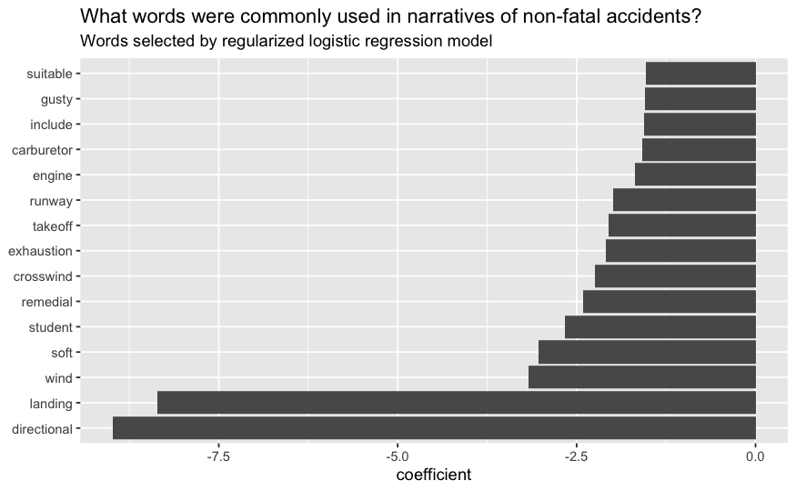

```r
# plot
df_plot %>%
  arrange(desc(coefs)) %>%
  top_n(-15) %>%
  ggplot(aes(x=reorder(words, coefs), y=coefs)) +
  geom_bar(stat = "identity") +
  coord_flip() +
  labs(y = "coefficient",
       x = NULL,
       title = "What words were commonly used in narratives of non-fatal accidents?",
       subtitle = "Words selected by regularized logistic regression model")
```

# Topic modeling using LDA

https://slcladal.github.io/topicmodels.html

```r
# for posterity, make the dtm again

# subset the data
tmp <- df %>%
  filter(InvestigationType == "Accident") %>% # remove incidents, which are always non-fatal
  mutate(InjuryType = ifelse(InjurySeverity %in% c("", "Non-Fatal", "Unavailable"), as.character(InjurySeverity), "Fatal")) %>%
  filter(InjuryType %in% c("Fatal", "Non-Fatal")) %>% # remove missing values
  mutate(InjuryTypeBin = ifelse(InjuryType=="Fatal", 1, 0))


# create corpus
corpus <- Corpus(VectorSource(tmp$probable_cause))

# remove line breaks, words, punctuation, numbers
line_break <- function(x) gsub("\\\\r\\\\n", " ", x)
docs.s <- tm_map(corpus, line_break)
```

```
transformation drops documents
```

```r
docs.s <- tm_map(docs.s, content_transformer(tolower))
```

```
transformation drops documents
```

```r
docs.s <- tm_map(docs.s, removeWords, stopwords("english"))
```

```
transformation drops documents
```

```r
docs.s <- tm_map(docs.s, removePunctuation, preserve_intra_word_dashes = TRUE)
```

```
transformation drops documents
```

```r
docs.s <- tm_map(docs.s, removeNumbers)
```

```
transformation drops documents
```

```r
docs.s <- tm_map(docs.s, removeWords, c("th"))
```

```
transformation drops documents
```

```r
docs.s <- tm_map(docs.s, stripWhitespace)
```

```
transformation drops documents
```

```r
# remove words that appear in less than 1%, or more than 80% of documents
ndocs <- length(corpus)
minDocFreq <- ndocs * 0.01
maxDocFreq <- ndocs * 0.8

dtm<- DocumentTermMatrix(docs.s, control = list(bounds = list(global = c(minDocFreq, maxDocFreq))))
```

```r
library(topicmodels)

# due to vocabulary pruning, we have empty rows in our DTM
# LDA does not like this. So we remove those docs from the
# DTM and the metadata
sel_idx <- slam::row_sums(dtm) > 0
dtm_lda <- dtm[sel_idx, ]
tmp_lda <- tmp[sel_idx, ]
# number of topics
K <- 10

# set random number generator seed
set.seed(123)

# compute the LDA model, inference via 1000 iterations of Gibbs sampling
topicModel <- LDA(dtm_lda, K, method="Gibbs", control=list(iter = 500, verbose = 25))
```

```r
# have a look a some of the results (posterior distributions)
tmResult <- posterior(topicModel)
# format of the resulting object
attributes(tmResult)
# length of vocab
nTerms(dtm_lda)
# topics are probability distribtions over the entire vocabulary
beta <- tmResult$terms   # get beta from results
dim(beta)                # K distributions over nTerms(DTM) terms
rowSums(beta) # should sum to 1

# for every document we have a probaility distribution of its contained topics
theta <- tmResult$topics
dim(theta)
```

149 words in the probable cause column 1010 words in the narrative column

```r
terms(topicModel, 10)
```

Consider trying a different alpha. Higher alpha priors for topics result in an even distribution of topics within a document. Low alpha priors ensure that the inference process distributes the probability mass on a few topics for each document.

```r
attr(topicModel, "alpha")

# K <- 10
# topicModel <- LDA(dtm_lda, K, method="Gibbs", control=list(iter = 500, verbose = 25, alpha = 1))
```

```r
# look at terms
terms(topicModel, 10)

# extract model coefs
tmResult <- posterior(topicModel)
theta <- tmResult$topics
beta <- tmResult$terms

# create topic names by pasting the 5 most common words
topicNames <- apply(terms(topicModel, 5), 2, paste, collapse = " ")  # reset topicnames
```

re-rank terms in order to favor less common words, similar to df-idf

```r
# re-rank top topic terms for topic names
topicNames <- apply(lda::top.topic.words(beta, 5, by.score = T), 2, paste, collapse = " ")
```

What are the most common topics in the entire collection?

```r
# What are the most probable topics in the entire collection?
topicProportions <- colSums(theta) / nDocs(dtm_lda)  # mean probablities over all entries
names(topicProportions) <- topicNames     # assign the topic names we created before
sort(topicProportions, decreasing = TRUE) # show summed proportions in decreased order
```

What are the most common topics in fatal versus non-fatal accidents?

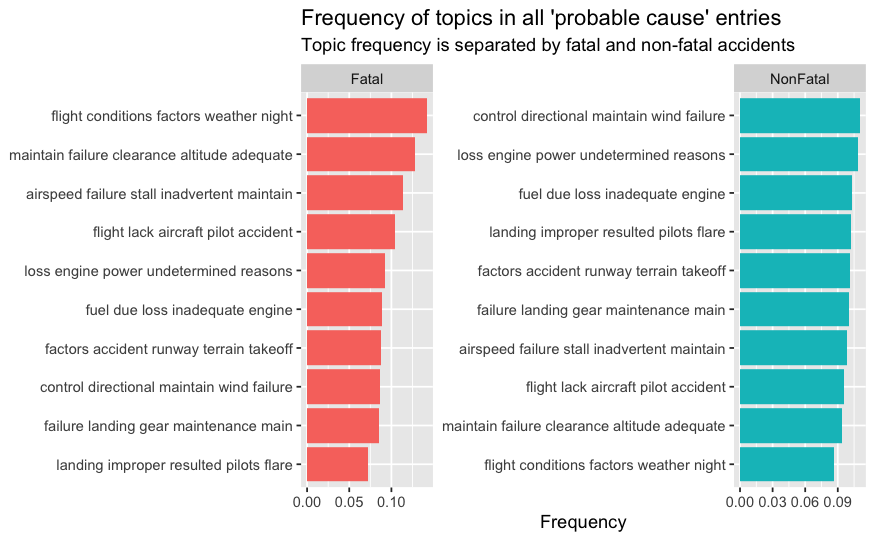

```r
 # mean probablities over all entries
fatalProportions <- colSums(theta[tmp_lda$InjuryType=="Fatal",]) / nDocs(dtm_lda[tmp_lda$InjuryType=="Fatal",])
nonfatalProportions <- colSums(theta[tmp_lda$InjuryType=="Non-Fatal",]) / nDocs(dtm_lda[tmp_lda$InjuryType=="Non-Fatal",])

tmp_plt <- data.frame(Fatal = fatalProportions,
                      NonFatal = nonfatalProportions,
                      Topic = topicNames) %>%
  pivot_longer(c(Fatal, NonFatal), names_to = 'InjuryType', values_to = 'freq') %>%
  mutate(Topic = tidytext::reorder_within(Topic, freq, InjuryType))


ggplot(tmp_plt, aes(x=Topic, y=freq, fill=InjuryType)) +
  geom_bar(stat = "identity") +
  theme(legend.position = "none") +
  coord_flip() +
  tidytext::scale_x_reordered() +
  facet_wrap(vars(InjuryType), scales = "free") +
  labs(y = "Frequency",
       x = NULL,
       title = "Frequency of topics in all 'probable cause' entries",
       subtitle = "Topic frequency is separated by fatal and non-fatal accidents")
```

Suppose you wanted to know what engine types are associated with “loss engine power undetermined reasons”

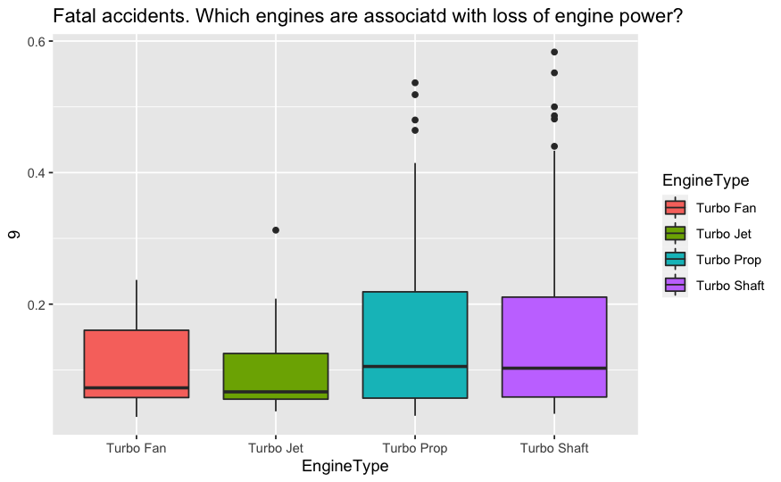

```r
# topic 10: loss engine power undetermined reasons
tmp_top <- cbind(tmp_lda, theta) %>%
  filter(AircraftCategory %in% c("Airplane", "Helicopter"),
         EngineType %in% c("Reciproacting", "Turbo Fan", "Turbo Jet", "Turbo Prop", "Turbo Shaft")) %>%
  mutate(Make = ifelse(grepl("ROBINSON", Make, fixed = T)==T, "ROBINSON", as.character(Make))) %>% # consolidate duplicate names
  mutate(Make = toupper(Make)) %>% # consolidate duplicate names
  mutate(MakeModel = paste(Make, Model, sep = " ")) %>%
  filter(InjuryType=="Fatal")

ggplot(tmp_top, aes(x=EngineType, y=`9`, fill=EngineType)) +
  geom_boxplot() +
  ggtitle("Fatal accidents. Which engines are associatd with loss of engine power?")
```

```r
# Compute the analysis of variance
res.aov <- aov(`9` ~ EngineType, data = tmp_top)
# Summary of the analysis
summary(res.aov)
```

```
             Df Sum Sq Mean Sq F value Pr(>F)
EngineType    3  0.062 0.02079   1.389  0.246
Residuals   270  4.040 0.01496
```

nothing significant.

[figure not shown]

```r
# topic 10: loss engine power undetermined reasons
tmp_top <- cbind(tmp_lda, theta) %>%
  filter(AircraftCategory %in% c("Airplane", "Helicopter"),
         EngineType %in% c("Reciproacting", "Turbo Fan", "Turbo Jet", "Turbo Prop", "Turbo Shaft")) %>%
  mutate(Make = ifelse(grepl("ROBINSON", Make, fixed = T)==T, "ROBINSON", as.character(Make))) %>% # consolidate duplicate names
  mutate(Make = toupper(Make)) %>% # consolidate duplicate names
  mutate(MakeModel = paste(Make, Model, sep = " ")) %>%
  group_by(MakeModel) %>%
  mutate(n = n()) %>%
  filter(n>7)

ggplot(tmp_top, aes(x=MakeModel, y=`6`, fill=MakeModel)) +
  geom_boxplot() +
  ggtitle("Fatal accidents. Which engines are associatd with loss of engine power?") +
  xlab("") +
  coord_flip() +
  theme(legend.position = "none")
```

```r
# Compute the analysis of variance
res.aov <- aov(`6` ~ MakeModel, data = tmp_top)
# Summary of the analysis
summary(res.aov)
```

```
             Df Sum Sq  Mean Sq F value Pr(>F)
MakeModel    18 0.1436 0.007978   1.127  0.325
Residuals   279 1.9745 0.007077
```

```r
# If ANOVA significant, then run TukeyHSD to get pairwise
as.data.frame(TukeyHSD(res.aov)$MakeModel) %>%
  filter(`p adj` <= 0.05) %>%
  arrange()
```

| diff | lwr | upr | p adj |
| --- | --- | --- | --- |

(no more interesting questions, move on).

Other ones to investigate:

In what states to bad pilots live?

```r
# get us map data
library(maps)
states <- map_data("state") %>% # download state data
  mutate(region = str_to_title(region))
# add the state abbreviation
states$State <- state.abb[match(states$region,state.name)]
```

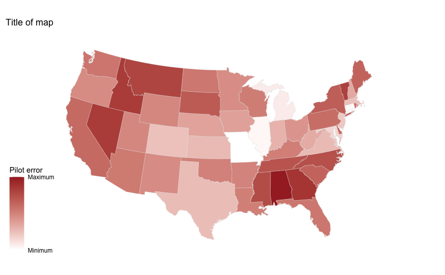

```r
tmp_top <- cbind(tmp_lda, theta) %>%
  filter(Country %in% c("United States")) %>%
  mutate(State = str_extract(Location, '\\b[^,]+$')) %>% # everything after the comma
  filter(State %in% states$State) %>% # remove puerto rico, etc
  group_by(State) %>%
  summarise(value = mean(`6`)) %>%
  right_join(states, by="State")
# tfmerged <- merge(states, tmp_top, sort = FALSE, by = "State")

library(ggthemes)
ggplot(data = tmp_top, mapping = aes(x = long, y = lat, group = group, fill = value)) +
  geom_polygon(color = "gray90", size = 0.1) +
  coord_map(projection = "albers", lat0 = 39, lat1 = 45) +
  scale_fill_gradient(
                      breaks=c(min(tfmerged$value),max(tfmerged$value)),
                      labels=c("Minimum","Maximum"),
                      low = "white",
                      high = "brown") +
  labs(title = "Title of map",
       fill = "Pilot error") +
  theme_map()
```

```r
tmp_top <- cbind(tmp_lda, theta) %>%
  filter(Country %in% c("United States")) %>%
  mutate(State = str_extract(Location, '\\b[^,]+$')) %>% # everything after the comma
  filter(State %in% states$State) %>% # remove puerto rico, etc
  group_by(State) %>%
  summarise(value = mean(`8`)) %>%
  right_join(states, by="State")
```

Which airports have the most dangerous runways to land on (4)?

[output not shown]

Which months are associated with bad weather accidents (9)?

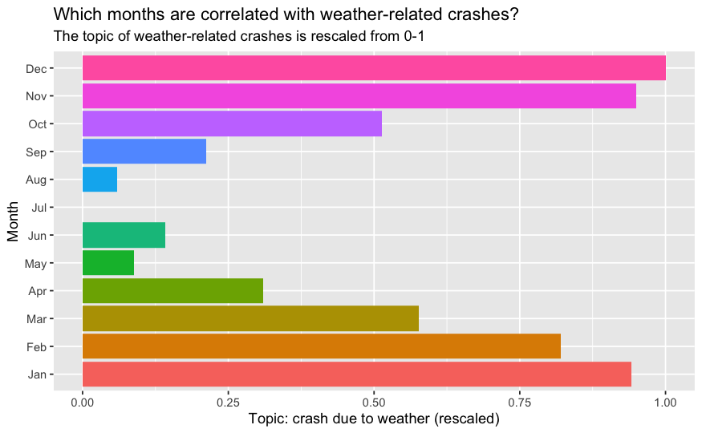

time-series

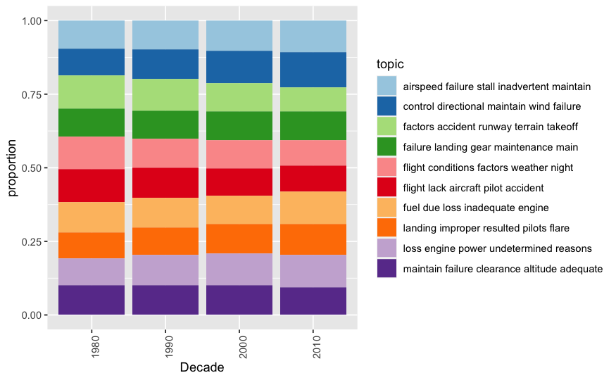

```r
tmp_top <- cbind(tmp_lda, theta) %>%
  #filter(InjuryType=="Fatal") %>% # this looks cooler
  mutate(EventDate = mdy(EventDate),
         Year = year(EventDate)) %>%
  mutate(Decade = case_when(
    Year >= 1980 & Year < 1990 ~ '1980',
    Year >= 1990 & Year < 2000 ~ '1990',
    Year >= 2000 & Year < 2010 ~ '2000',
    Year >= 2010 & Year < 2020 ~ '2010'
  )) %>%
  group_by(Decade) %>%
  summarise_at(as.character(seq(1,10)), mean) %>%
  rename_at(vars(as.character(seq(1,10))), ~ topicNames) %>% # add topic names
  pivot_longer(cols = -Decade, names_to = "topic", values_to = "value") %>%
  drop_na()

# plot
ggplot(tmp_top, aes(x=Decade, y=value, fill=topic)) +
  geom_bar(stat = "identity") + ylab("proportion") +
  scale_fill_brewer(palette="Paired") +
  theme(axis.text.x = element_text(angle = 90, hjust = 1))
```

```r
NA
NA
```